# Primeiro Relatório de FIS225 - Circuíto RC

### Alunos:

Gabriel Vita Silva Franco **(79208)**  
Gabriela Milane Furlani **(83783)**  
Samuel da Silva Guimarães **(81817)**

## Objetivos

O objetivo dessa atividade prática é verificar como a diferença de potencial de um capacitor varia em função do tempo, especificamente quando o mesmo é sujeito ao processo de descarga. Além disso, espera-se que a interpretação do significado do produto da resistência pela capacitância em um circuito RC, bem como sua importância em aplicações tecnologicas, sejam esclarecidas.

## Introdução

Os circuitos RC são circuitos onde resistores e capacitores são conectados, normalmente com uma fonte de alimentação em série com o circuito para carregá-lo. Eles tem uma ampla aplicação prática de sistemas de distribuição de potência em residências e automóveis. Alguns exemplos mais especificados são: motores, sistemas de distribuição de energia elétrica para uso comercial, industrial e doméstico, lâmpadas, aparelhos eletrodomésticos, rádio, máquinas fotográficas, entre outros.

Abaixo a **figura 1** mostra um circuito RC onde a associação dos componentes é em série. Quando a chave está fechada em $c$ o capacitor é carregado pela *fem* através do resistor $R$. Após o capacitor estar carregado, a chave é comutada para $d$ e o capacitor é descarregado através de $R$. Pode-se medir facilmente a diferença de potencial $V_{f}\ (=IR)$ entre os terminais do resistor para determinar a corrente i e também medir a diferença de potencial $\Delta VC\ (=\frac{q}{C})$ entre os terminais do capacitor para determinar a carga $q$ **[1]**.

[figure not shown]

\begin{align} Figura\ 1 - Circuito\ RC,\ que\ contém\ um\ capacitor\ C\ em\ série\ com\ resistor\ R,\ e\ uma\ fonte\ de\ potencial\ V_{f}. \end{align}

Os capacitores possuem muitas aplicações que usam sua propriedade de armazenar carga e energia, por isso é de grande interesse saber como são carregados e descarregados. O simples processo de carregar e descarregar um capacitor, verifica-se uma situação na qual ocorrem variações com o tempo das correntes, das voltagens e das potências **[2]**.

### Avaliando a descarga de um capacitor

O processo de carregar o capacitor é essencial e indispensável para que o processo de descarga ocorra. Entretanto, nosso objetivo em tal prática é avaliar o processo em que o capacitor esteja descarregando. Para analisar a situação de descarga considere que o capacitor esteja com uma carga $Q_{0}$, a seguir removemos a bateria do circuito RC e conectamos a chave no ponto $d$. A partir de então damos partida para o cronômetro em $t=0$, nesse instante $q = Q_{0}$. Assim, o capacitor se descarrega através do resistor e sua carga diminui até $0$ **[2]**.

#### Obtenção das expressões de descarga

Através da lei da malhas de Kirchhoff para o caso da descarga temos que: $$Ri(t)+\frac{q(t)}{C} = 0$$
$$i(t) = \frac{dq}{dt} = - \frac{q(t)}{RC}\ \ (1)$$
A corrente $i$ agora é negativa devido ao fato da carga positiva está deixando a placa do capacitor. No instante $t=0$, quando $q = Q_{0}$, a corrente inicial é dada por $I_{0} = -\frac{Q_{0}}{RC}$. Para determinarmos $q$ em função do tempo basta integrarmos a expressão **(1)**.

$$\int_{Q_{0}}^{q} \frac{dq'}{q'} = -\frac{1}{RC}\int_{0}^{t} dt'$$
$$\ln{\frac{q(t)}{Q_{0}}} = - \frac{t}{RC}$$
$$q(t) = Q_{0}e^{-\ t\ /\ RC}\ (2)$$

[figure not shown]

\begin{align} Figura\ 2 - Carga\ q\ em\ função\ do\ tempo \end{align}

A corrente $i$ é derivada da expressão anterior: $$i(t) = \frac{dq}{dt} = - \frac{Q_{0}}{RC}e^{-\ t\ /\ RC} = I_{0}e^{-\ t\ /\ RC}\ (3)$$

[figure not shown]

\begin{align} Figura\ 3 - Corrente\ i\ em\ função\ do\ tempo \end{align}  
Sabendo como a corrente varia no circuito durante a descarga no capacitor estamos aptos a encontrar como as diferenças de potencial entre o resistor **($V_{de}$)** e entre o capacitor **($V_{ef}$)** variam com o tempo, então obtemos as seguintes relações:

$$V_{de} = \frac{-Q}{C}e^{-\ t\ /\ RC}\ (4)$$
$$V_{ef} = \frac{Q}{C}e^{-\ t\ /\ RC}\ (5)$$

Dessas equações podemos notar que o fator $e^{-\ t\ /\ RC}$ governa a dinâmica de todas as grandezas relevantes nesse processo de descarga, indicando um decrescimento exponencial. Devido a essa importância a constante $RC$ presente nesse decrescimento é usada para descrever o circuito, sendo chamada de constante de relaxação, definida como: $$\tau = RC\ \ (6)$$

## Materiais

- Placa de circuito Vernier (VCB), com chave **S**
- Capacitor com capacitância igual a **$10\ \mu$F**
- Resistores de resistência igual a **$22\ k\Omega$**, **$47\ k\Omega$** e **$100\ k\Omega$**
- Interface Vernier com sensor de voltagem
- Cinco fios com garra jacaré com isolamento
- Fonte de alimentação de, no mínimo, **$5 V$**
- Computador com o programas **Logger Pro** instalado corretamente

## Metodologia

Inicialmente foi montada a placa de circuito Vernier usando os fios com garra jacaré ligando os seguintes pontos da placa: **1-32, 33-18, 19-20, 21-35, 35-34**. A placa e os cabos com garra jacaré estão mostrados na **figura 4** e um diagrama mostrando as conexões está ilustrados na **figura 5**.

[figure not shown]

\begin{align} Figura\ 4 - Placa\ de\ circuitos\ Vernier\ e\ fios\ com\ garra\ jacaré \end{align}

[figure not shown]

\begin{align} Figura\ 5 - Diagrama\ da\ configuração\ inicial\ do\ circuito\ para\ o\ resistor\ de\ 100\ k\Omega \end{align}

Tendo feito isso, a fonte de alimentação foi ligada no circuito nos encaixes **J1** e **J2** da placa, enquanto que o sensor de voltagem foi ligado nos pontos **20** e **21** da placa, paralelo ao capacitor de **10 $\mu$F**. Além disso, o sensor também foi ligado à interface Vernier e a mesma foi ligada ao computador.

Com tudo conectado, foi iniciado o programa Logger Pro no computador ligado à interface Vernier. A interface desse software está ilustrada na **figura 6**. Na interface é exibida um gráfico da voltagem em função do tempo e uma leitura instantânea da voltagem medida pelo sensor. Para poder calcular corretamente os valores de voltagem o sistema é calibrado marcando o estado atual como **0V**, através do botão com o ícone **$\varnothing$** circulado na **figura 6**.

Após a calibração, a fonte foi ajustada lentamente até um valor próximo de **5V**, baseado na indicação da voltagem mostrada pelo programa Logger Pro. A partir desse ponto, tendo o capacitor carregado, foi iniciado a captura de dados do sensor através da função *"Collect"* do software usado, também circulado na **figura 6**. Simultaneamente ao inicio da captura foi deslocada a chave S da placa Vernier para a posição de descarregamento do circuito, ou seja, para baixo. Ao fim do descarregamento do capacitor, o botão *"Stop"* foi pressionado e os dados coletados pelo programa foram exportados para serem usados para a criação dos gráficos inseridos na seção de Resultados abaixo.

[figure not shown]

\begin{align} Figura\ 6 - Interface\ do\ programa\ Logger\ Pro \end{align}

Ao termino da medição da voltagem para o resistor de **100 k$\Omega$**, os fios com garra jacaré ligados aos pontos **33-18** e **19-20** foram trocados para as posições **33-16** e **17-20**, para o experimento com o resistor de **47 k$\Omega$**. A chave S foi religada, ou seja, posicionada para cima, e novamente os passos relacionados a medição da voltagem no software instalado foram repetidos. Numa última medição novamente os fios **33-16** e **17-20** foram reposicionados nas posições **33-14** e **15-20**, para fazer o experimento com o resistor de **22 k$\Omega$**.

## Resultados experimentais e Discussão

Seguindo o procedimento descrito na seção anterior obtivemos os dados descritos abaixo.

Para o capacitor de **100 k$\Omega$** os dados estão descritos na tabela 1, para o capacitor de **47 k$\Omega$** os dados estão descritos na tabela 2, e por fim, para o capacitor de **22 k$\Omega$** os dados estão descritos na tabela 3.

Juntamente com as tabelas, foram feitos 3 gráficos em uma escala linear, e mais 3 gráficos com o eixo dos valores do potencial na escala logarítmica, tornando o resultado numa reta. Por fim, as três retas foram colocadas num mesmo gráfico para comparação entre elas.

### Resistor 100k

| Tempo(s) | Potencial(V) |
| --- | --- |
| 0.0 | 4.944 |
| 0.1 | 4.456 |
| 0.2 | 4.020 |
| 0.3 | 3.627 |
| 0.4 | 3.266 |
| 0.5 | 2.940 |
| 0.6 | 2.640 |
| 0.7 | 2.371 |
| 0.8 | 2.124 |
| 0.9 | 1.899 |
| 1.0 | 1.694 |
| 1.1 | 1.507 |
| 1.2 | 1.336 |
| 1.3 | 1.181 |
| 1.4 | 1.042 |
| 1.5 | 0.915 |
| 1.6 | 0.804 |
| 1.7 | 0.700 |
| 1.8 | 0.608 |
| 1.9 | 0.526 |
| 2.0 | 0.450 |
| 2.1 | 0.383 |
| 2.2 | 0.326 |
| 2.3 | 0.276 |
| 2.4 | 0.232 |
| 2.5 | 0.190 |
| 2.6 | 0.159 |
| 2.7 | 0.130 |

#### Tabela 1 - Dados do resistor de $100k\Omega$

### Resistor 47k

[output not shown]

#### Tabela 2 - Dados do resistor de $47k\Omega$

### Resistor 22k

| Tempo(s) | Potencial(V) |
| --- | --- |
| 0.0 | 4.270 |
| 0.1 | 2.776 |
| 0.2 | 1.804 |
| 0.3 | 1.165 |
| 0.4 | 0.751 |
| 0.5 | 0.481 |
| 0.6 | 0.307 |
| 0.7 | 0.197 |
| 0.8 | 0.127 |
| 0.9 | 0.080 |
| 1.0 | 0.051 |
| 1.1 | 0.032 |
| 1.2 | 0.023 |
| 1.3 | 0.013 |
| 1.4 | 0.010 |

#### Tabela 3 - Dados do resistor de $22k\Omega$

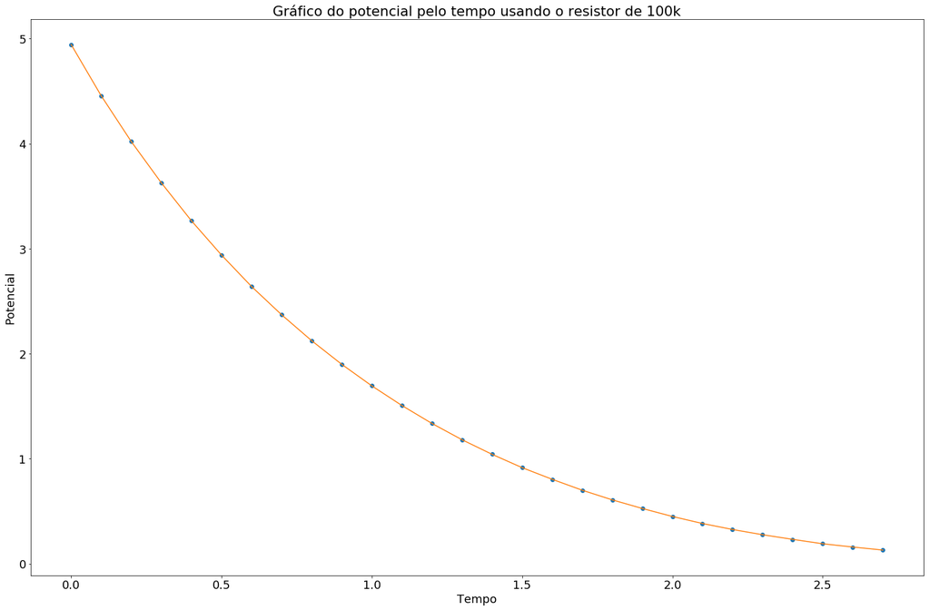

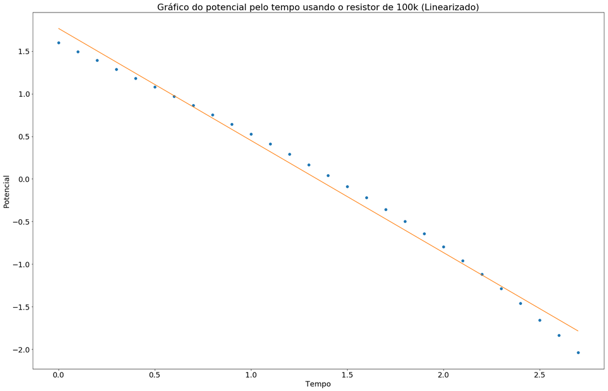

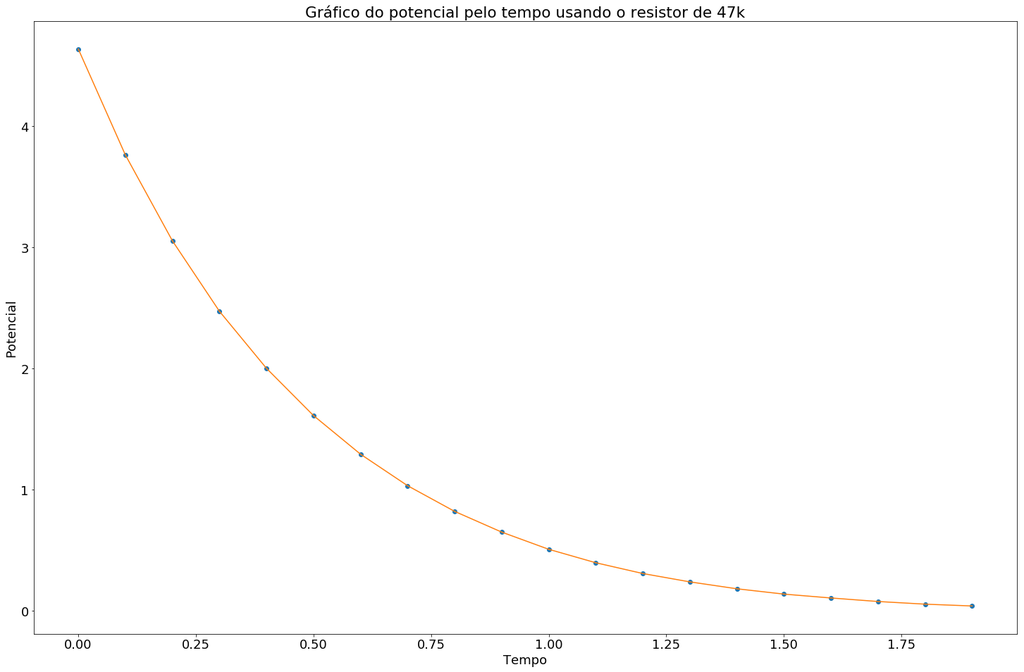

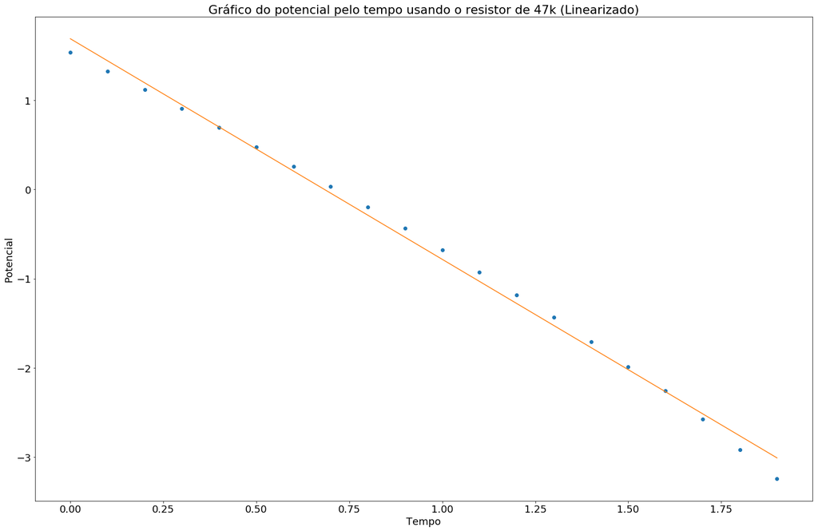

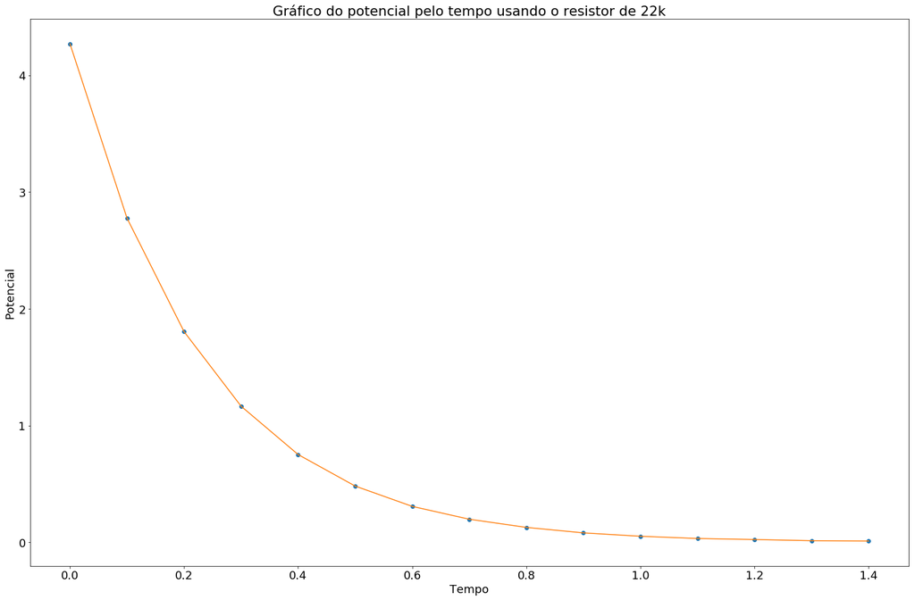

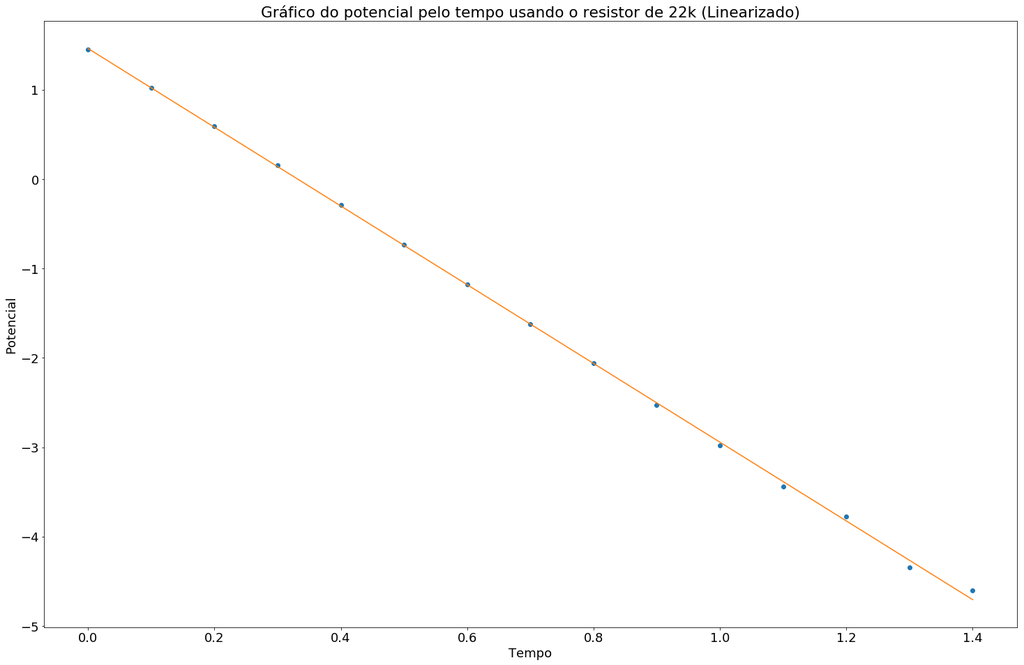

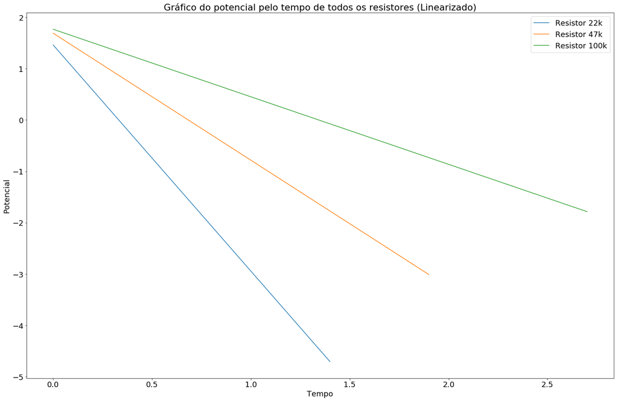

| Tempo(s) | Potencial(V) |
| --- | --- |
| 0.0 | 4.944 |
| 0.3 | 3.627 |
| 0.6 | 2.640 |
| 0.9 | 1.899 |
| 1.2 | 1.336 |
| 1.5 | 0.915 |
| 1.8 | 0.608 |
| 2.1 | 0.383 |
| 2.4 | 0.232 |
| 2.7 | 0.130 |

#### Tabela 4 - 10 pontos usados para o resistor de $100k\Omega$

[output not shown]

#### Tabela 5 - 10 pontos usados para o resistor de $47k\Omega$

[output not shown]

#### Tabela 6 - 10 pontos usados para o resistor de $22k\Omega$

Usando novamente o software que construiu os gráficos, podemos então encontrar as inclinações das retas por ele produzido. Igualmente podemos calcular por via da melhor reta visual as inclinações encontradas no gráfico feito no papel semi-logarítmo. Para as inclinações dos gráficos feitos computacionalmente, seguindo a equação $y = Ax + B$, encontramos os seguintes valores:

$$A_{R=100k\Omega} = -1.31\pm0.03\ s^{-1}$$
$$A_{R=47k\Omega} = -2.47\pm0.04\ s^{-1}$$
$$A_{R=22k\Omega} = -4.40\pm0.03\ s^{-1}$$

A unidade dada para essa inclinação é encontrada ao analisar o relacionamento de $A$ com o $\tau$ da equação **(6)** posteriormente. Para as retas desenhadas no papel, foi necessário encontrar pontos sobre a melhor reta visual para serem usados para o cálculo da inclinação. Os pontos usados para cada gráfico foram:

| $t_{inicial}\ (s)$ | $V_{inicial}(V)$ | $t_{final}(s)$ | $V_{final}(V)$ |
| --- | --- | --- | --- |
| 0.00$\pm$0.02 | 5.8$\pm$0.01 | 1.4$\pm$0.02 | 0.0140$\pm$0.0001 |
| 0.00$\pm$0.02 | 5.8$\pm$0.01 | 1.8$\pm$0.02 | 0.0920$\pm$0.0001 |
| 0.00$\pm$0.02 | 5.8$\pm$0.01 | 2.6$\pm$0.02 | 0.190$\pm$0.001 |

#### Tabela 7 - Pontos usados para o cálculo da inclinação

Depois disso foi aplicada função ln nos valores de potencia, e usada a fórmula $A' = \frac{\ln{(y_{final})} - \ln{(y_{inicial})}}{x_{final} - x_{inicial}}$. Os valores encontrados para a inclinação usando a melhor reta no gráfico feito a mão e este método foram: $$A'_{R=100k\Omega} = -1.3\pm0.1\ s^{-1}$$
$$A'_{R=47k\Omega} = -2.3\pm0.1\ s^{-1}$$
$$A'_{R=22k\Omega} = -4.3\pm0.1\ s^{-1}$$

$$\tau_{R=100k\Omega} = 0.76\pm0.02\ s$$
$$\tau_{R=47k\Omega} = 0.405\pm0.007\ s$$
$$\tau_{R=22k\Omega} = 0.227\pm0.002\ s$$
$$\tau'_{R=100k\Omega} = 0.76\pm0.06\ s$$
$$\tau'_{R=47k\Omega} = 0.43\pm0.01\ s$$
$$\tau'_{R=22k\Omega} = 0.232\pm0.005\ s$$

Em comparação, usando a fórmula **(6)** direto para os valores de $R$ e $C$ conhecidos do equipamento usado o $\tau_{esperado}$ de para cada resistor é:
$$\tau_{esperado(100k\Omega)} = 1.00\ s$$
$$\tau_{esperado(47k\Omega)} = 0.47\ s$$
$$\tau_{esperado(22k\Omega)} = 0.22\ s$$

$$E\%_{R=100k\Omega} = 24.00\%$$
$$E\%_{R=47k\Omega} = 13.830\%$$
$$E\%_{R=22k\Omega} = 3.182\%$$
$$E'\%_{R=100k\Omega} = 24.00\%$$
$$E'\%_{R=47k\Omega} = 8.51\%$$
$$E'\%_{R=22k\Omega} = 5.455\%$$

## Conclusão

Pode-se notar que de fato o menor erro foi encontrado para o resistor de $22k\Omega$, o que é um pouco incomum considerando que seu $\tau$ é o menor de todos, e portanto teria a descarga mais rápida, possuindo então menos pontos medidos de potencial, e deveria dessa forma ter a reta menos precisa. Todavia, como pode ser visto mais claramente com os gráficos feitos computacionalmente, que mesmo aplicando a função $\ln$ na equação **(5)**, o resultado não é um reta perfeita, praticamente uma curva dependendo dos pontos usados. Considerando que o grupo deste trabalho repetiu este experimento varias vezes e pegou destes experimentos o conjunto de dados que geravam a melhor linearização, e mesmo assim os resistores de $47k\Omega$ e $100k\Omega$ tem um erro maior, acreditamos que talvez houvesse um defeito no equipamento ou um mal-contato, que fez com que um outro termo fosse acrescido a equação **(5)** de forma que mesmo ao aplicar a função $\ln$, não seria encontrada uma reta. De fato, como o erro da reta feita a mão, somente com 10 pontos para o resistor de $47k\Omega$ tem erro menor que o computacional, a teoria de que os pontos experimentais podem conter um erro tem um argumento válido.

## Referências Bibliográficas

**1.** Resnick, e Halliday, D, Física V3, Rio de Janeiro: LTL, 2004.  
**2.** Freedman, e Young. Eletromagnetismo, V3.10° Edição, 2004.